# Problem Set 03 - Answer Key

Lauren Sullivan, BIO_SC 8002_01

Due Feb 11, 2022

## Instructions

### Data Transformation

**The problem set this week involves transforming and exploring a new dataset on the shiny rates of Pokemon in Pokemon Go. For those not familiar with the game, Pokemon appear infrequently as their shiny version, which is a different color. For this week we have a dataset of shiny rates for Pokemon. We will be using this dataset in combination with the dataset from last week to perform some EDA.**

## Setup

### Setup

Set up your code so you have an appropriate preamble that explains the work, clears the console, sets your working directory, and loads in the data.

```r
###############
#
# 03 PROBLEM SET
#
# DUE:        February 11, 2022
#
# CREATED BY: Lauren Sullivan
# FILES:      "pokemon_dat.csv"
#             "shiny_rates.csv"
#
###############


########### setup
rm(list=ls())

library(tidyverse)

########### data
pokedat <- read_csv("../data/pokemon_tidy.csv")
shiny <- read_csv("../data/shiny_rates.csv")
```

## Question 1

### Question 1

**We will first be working with the “shiny_rates.csv” dataset, that gives the shiny rates of all Pokemon that can be caught in the wild.**

**Q1a** Read in your data and summarize all variables.

```r
shiny
```

```
## # A tibble: 102 × 4
##    Number Pokemon_Name   Shiny_Rate Number_Caught
##     <dbl> <chr>          <chr>              <dbl>
##  1      1 Bulbasaur      1/335               5699
##  2      4 Charmander     1/277               1940
##  3      7 Squirtle       1/398               1592
##  4     10 Caterpie       1/680               4085
##  5     16 Pidgey         1/486               2430
##  6     19 Rattata        1/390              12113
##  7     23 Ekans          1/600               6600
##  8     29 Nidoran_female 1/717               6453
##  9     32 Nidoran_male   1/542               7595
## 10     41 Zubat          1/525              22059
## # … with 92 more rows
```

```r
summary(shiny)
```

```
##      Number       Pokemon_Name        Shiny_Rate        Number_Caught
##  Min.   :  1.00   Length:102         Length:102         Min.   :   70
##  1st Qu.: 95.25   Class :character   Class :character   1st Qu.: 1576
##  Median :208.00   Mode  :character   Mode  :character   Median : 2795
##  Mean   :212.63                                         Mean   : 4586
##  3rd Qu.:319.50                                         3rd Qu.: 6366
##  Max.   :572.00                                         Max.   :29368
```

**Q1b** Before we can start working with the shiny rate data we need to transform the column “Shiny_Rate” into something useable, as it was entered as a fraction, but this is currently a character. Create a new variable in your shiny dataset that has shiny rate values as numbers.

```r
shiny_1b <- shiny %>%
              separate(Shiny_Rate, into = c("num", "denom"), sep = "/",
                       convert = TRUE) %>%
              mutate(Rate = num / denom)
shiny_1b
```

```
## # A tibble: 102 × 6
##    Number Pokemon_Name     num denom Number_Caught    Rate
##     <dbl> <chr>          <int> <int>         <dbl>   <dbl>
##  1      1 Bulbasaur          1   335          5699 0.00299
##  2      4 Charmander         1   277          1940 0.00361
##  3      7 Squirtle           1   398          1592 0.00251
##  4     10 Caterpie           1   680          4085 0.00147
##  5     16 Pidgey             1   486          2430 0.00206
##  6     19 Rattata            1   390         12113 0.00256
##  7     23 Ekans              1   600          6600 0.00167
##  8     29 Nidoran_female     1   717          6453 0.00139
##  9     32 Nidoran_male       1   542          7595 0.00185
## 10     41 Zubat              1   525         22059 0.00190
## # … with 92 more rows
```

**Q1c** What does the distribution of shiny rates look like? Are there any issues you see? How would you interpret this data distribution in terms of what it actually means for shiny rates in the wild?

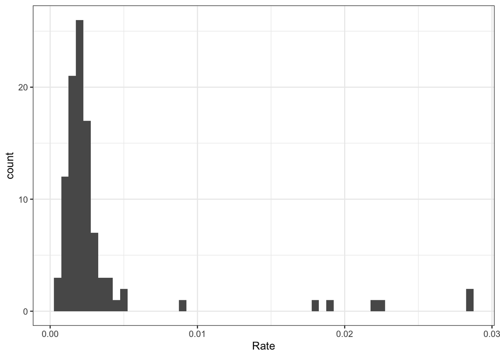

```r
ggplot(shiny_1b)+
  geom_histogram(aes(x = Rate), binwidth = 0.0005)+
  theme_bw()
```

```r
#The data is very right skewed, which means there are a lot of pokemon
#   with vary rare shiny forms (e.g. very low shiny rates), but there
#   are just a few that have decently high shiny rates.
```

**Q1d** Is there a relationship between shiny rate and the number of pokemon caught? I would suggest transforming your data because the values are on such different scales. How do you interpret your results?

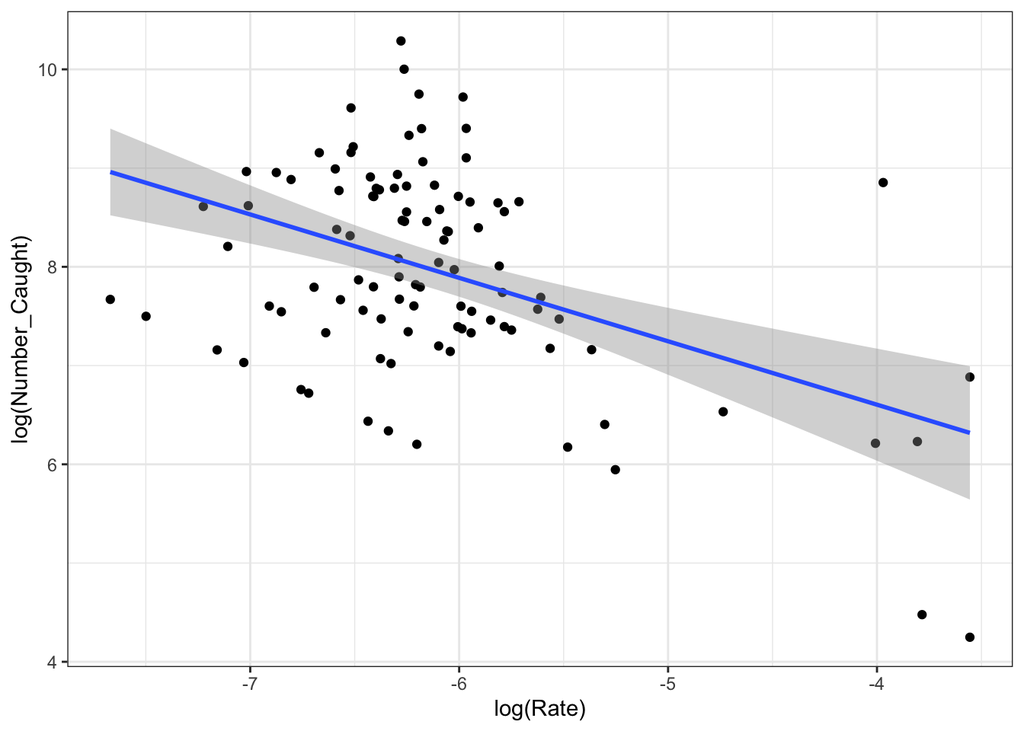

```r
ggplot(shiny_1b, aes(x = log(Rate), y = log(Number_Caught)))+
  geom_point()+
  geom_smooth(method = lm, se = TRUE)+
  theme_bw()
```

```r
#When you log transform both variables, you see a negative relationship
#   between shiny rate and the number of pokemon caught. To me, this
#   indicates that the pokemon are not evenly sampled. If shiny rate did
#   not depend on the number of Pokemon of that species caught, then
#   you would see no trend.  However what we see is that Pokemon with
#   the highest shiny rates are also caught the least often, and vice versa
#   I believe more Pokemon of each species need to be caught (especially
#   those with currently high shiny rates) to see if this relationship
#   still holds.
```

**Q1e** What Pokemon have the highest shiny rates? The lowest? What is Krabby’s shiny rate?

```r
shiny_1d <- shiny_1b %>%
              arrange(Rate)

#Lowest Shiny Rate
head(shiny_1d)
```

```
## # A tibble: 6 × 6
##   Number Pokemon_Name   num denom Number_Caught     Rate
##    <dbl> <chr>        <int> <int>         <dbl>    <dbl>
## 1    158 Totodile         1  2143          2143 0.000467
## 2    140 Kabuto           1  1806          1806 0.000554
## 3    427 Buneary          1  1373          5493 0.000728
## 4    347 Anorith          1  1285          1285 0.000778
## 5     86 Seel             1  1221          3665 0.000819
## 6    335 Zangoose         1  1131          1131 0.000884
```

```r
#Highest Shiny Rate
tail(shiny_1d)
```

```
## # A tibble: 6 × 6
##   Number Pokemon_Name   num denom Number_Caught   Rate
##    <dbl> <chr>        <int> <int>         <dbl>  <dbl>
## 1    436 Bronzor          1    55           499 0.0182
## 2     95 Onix             1    53          6999 0.0189
## 3    349 Feebas           1    45           508 0.0222
## 4    366 Clamperl         1    44            88 0.0227
## 5    131 Lapras           1    35            70 0.0286
## 6    227 Skarmory         1    35           976 0.0286
```

```r
#Krabby's Shiny Rate is 0.004
shiny_1d %>% filter(Pokemon_Name == "Krabby")
```

```
## # A tibble: 1 × 6
##   Number Pokemon_Name   num denom Number_Caught  Rate
##    <dbl> <chr>        <int> <int>         <dbl> <dbl>
## 1     98 Krabby           1   250          1756 0.004
```

## Question 2

### Question 2

**Now that we understand more about each Pokemon’s shiny rate, let’s combine this knowledge with our data from last week on Pokemon types and stats. We will start by exploring `pokemon_dat_cleaned.csv`.**

**Q2a** Now read in the “pokemon_dat_cleaned.csv” dataset - this is the cleaned version we created last week. Again, summarize all variables.

```r
pokedat
```

```
## # A tibble: 572 × 15
##    Number Name    Type_1 Type_2 Total    HP Attack Defense Speed Gener…¹ isLeg…²
##     <dbl> <chr>   <chr>  <chr>  <dbl> <dbl>  <dbl>   <dbl> <dbl>   <dbl> <lgl>
##  1      1 Bulbas… Grass  Poison   318    45     49      49    45       1 FALSE
##  2      2 Ivysaur Grass  Poison   405    60     62      63    60       1 FALSE
##  3      3 Venusa… Grass  Poison   525    80     82      83    80       1 FALSE
##  4      4 Charma… Fire   <NA>     309    39     52      43    65       1 FALSE
##  5      5 Charme… Fire   <NA>     405    58     64      58    80       1 FALSE
##  6      6 Chariz… Fire   Flying   534    78     84      78   100       1 FALSE
##  7      7 Squirt… Water  <NA>     314    44     48      65    43       1 FALSE
##  8      8 Wartor… Water  <NA>     405    59     63      80    58       1 FALSE
##  9      9 Blasto… Water  <NA>     530    79     83     100    78       1 FALSE
## 10     10 Caterp… Bug    <NA>     195    45     30      35    45       1 FALSE
## # … with 562 more rows, 4 more variables: Color <chr>, Pr_Male <dbl>,
## #   Height_m <dbl>, Weight_kg <dbl>, and abbreviated variable names
## #   ¹Generation, ²isLegendary
```

```r
summary(pokedat)
```

```
##      Number          Name              Type_1             Type_2
##  Min.   :  1.0   Length:572         Length:572         Length:572
##  1st Qu.:143.8   Class :character   Class :character   Class :character
##  Median :286.5   Mode  :character   Mode  :character   Mode  :character
##  Mean   :286.5
##  3rd Qu.:429.2
##  Max.   :572.0
##
##      Total             HP             Attack          Defense
##  Min.   :180.0   Min.   :  1.00   Min.   :  5.00   Min.   :  5.00
##  1st Qu.:318.0   1st Qu.: 50.00   1st Qu.: 52.00   1st Qu.: 50.00
##  Median :416.5   Median : 65.00   Median : 73.00   Median : 65.00
##  Mean   :412.6   Mean   : 67.71   Mean   : 74.34   Mean   : 69.97
##  3rd Qu.:495.0   3rd Qu.: 80.00   3rd Qu.: 94.25   3rd Qu.: 85.00
##  Max.   :720.0   Max.   :255.00   Max.   :165.00   Max.   :230.00
##
##      Speed          Generation   isLegendary        Color
##  Min.   :  5.00   Min.   :1.00   Mode :logical   Length:572
##  1st Qu.: 45.00   1st Qu.:1.00   FALSE:541       Class :character
##  Median : 65.00   Median :3.00   TRUE :31        Mode  :character
##  Mean   : 65.57   Mean   :2.76
##  3rd Qu.: 85.00   3rd Qu.:4.00
##  Max.   :160.00   Max.   :5.00
##
##     Pr_Male          Height_m        Weight_kg
##  Min.   :0.0000   Min.   : 0.200   Min.   :  0.10
##  1st Qu.:0.5000   1st Qu.: 0.610   1st Qu.: 10.00
##  Median :0.5000   Median : 0.990   Median : 28.50
##  Mean   :0.5597   Mean   : 1.156   Mean   : 56.23
##  3rd Qu.:0.5000   3rd Qu.: 1.400   3rd Qu.: 60.42
##  Max.   :1.0000   Max.   :14.500   Max.   :950.00
##  NA's   :55
```

**Q2b** Using `geom_boxplot()`, graph the range of pokemon mass by their `Type_1`.

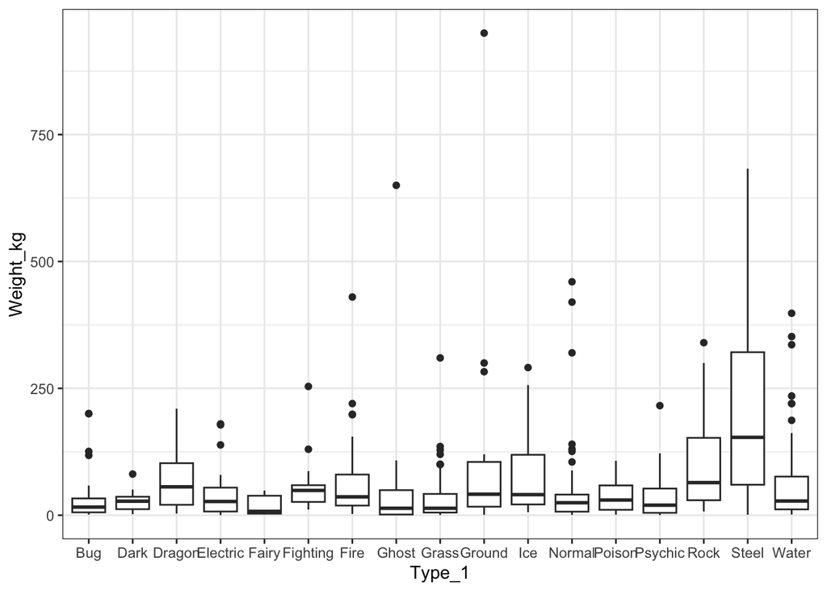

```r
ggplot(pokedat)+
  geom_boxplot(aes(x = Type_1, y = Weight_kg))+
  theme_bw()
```

**Q2c**

You will notice your graph is not very satisfying. One problem is the `Type_1` lables are all overlapping. How would you fix this? Also, order the x-axis by the median values so you can visualize the pattern better, and re-label the axes so they are understandable.

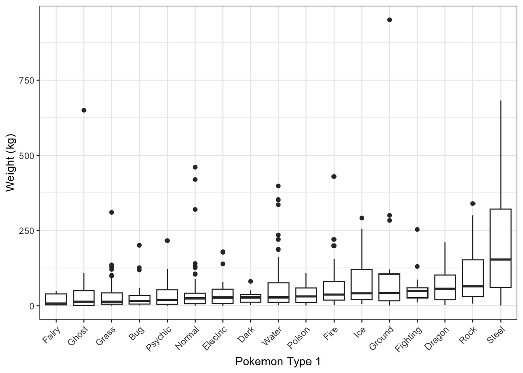

```r
ggplot(pokedat)+
  geom_boxplot(aes(x = reorder(Type_1, Weight_kg, FUN = median),
                   y = Weight_kg))+
  theme_bw()+
  theme(axis.text.x = element_text(angle = 45, hjust = 1))+
  labs(x = "Pokemon Type 1", y = "Weight (kg)")
```

**Q2d**

Boxplots can be useful, but it is also sometimes great to look at the actual data points. Re-create this graph using data points instead of the boxplots. Make sure we can see all the points within each category as they will overlap significantly.

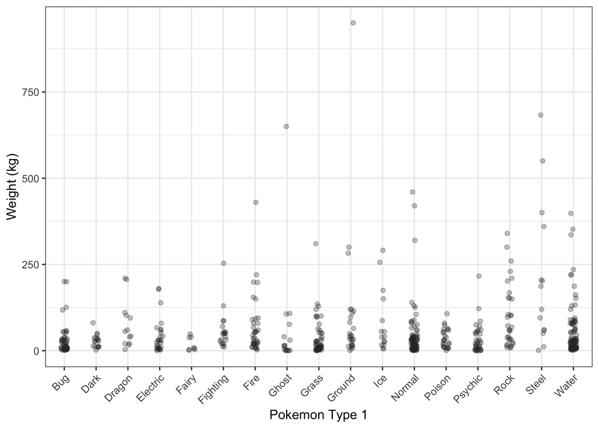

```r
ggplot(pokedat)+
  geom_jitter(aes(x = Type_1, y = Weight_kg), width = 0.1, color = "gray20",
              alpha = 0.3)+
  theme_bw()+
  theme(axis.text.x = element_text(angle = 45, hjust = 1))+
  labs(x = "Pokemon Type 1", y = "Weight (kg)")
```

**Q2e**

Now explore the distribution of `Weight_kg` across Pokemon with different `Type_1`.

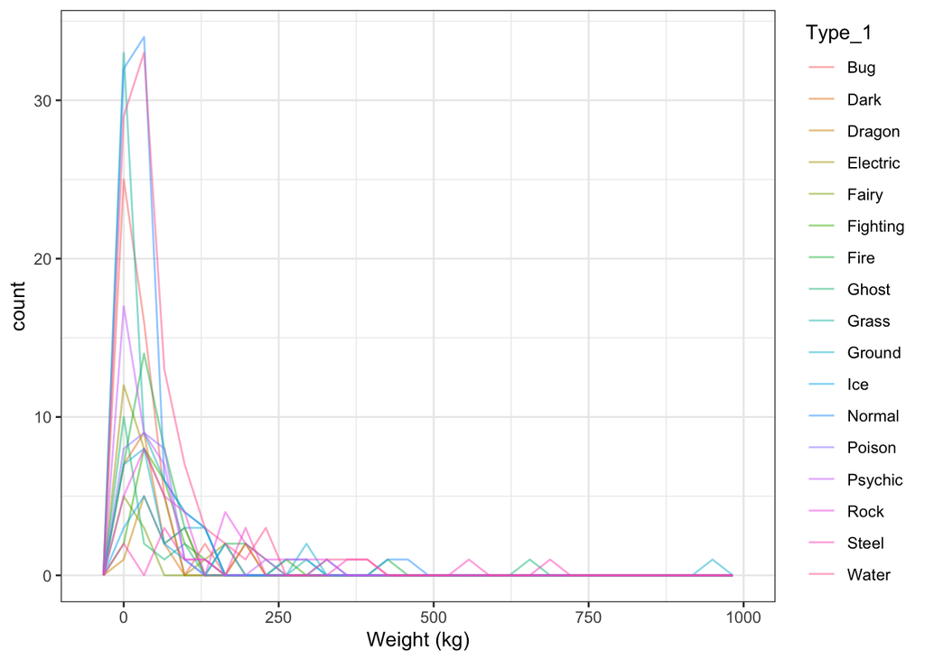

```r
ggplot(pokedat)+
  geom_freqpoly(aes(x = Weight_kg, color = Type_1), alpha = 0.5)+
  theme_bw()+
  labs(x = "Weight (kg)")
```

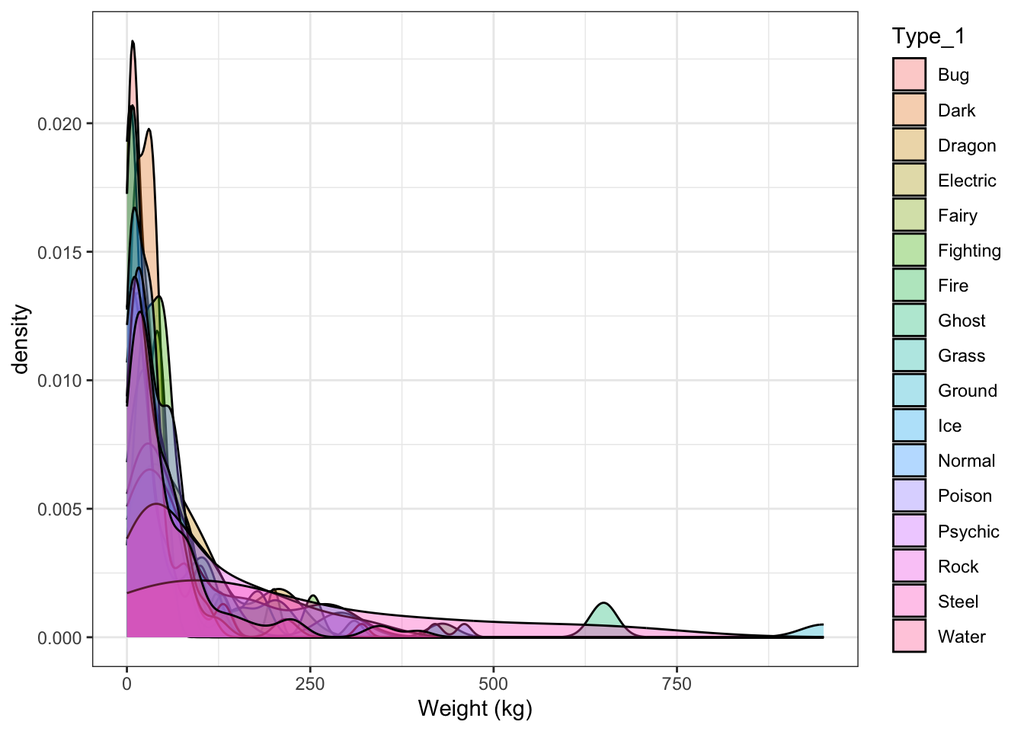

```r
#OR

ggplot(pokedat)+
  geom_density(aes(x = Weight_kg, fill = Type_1), alpha = 0.35)+
  theme_bw()+
  labs(x = "Weight (kg)")
```

## Question 3

### Question 3

**Ok, now it is time to merge the two datasets together and see what we can learn about Pokemon shiny rates and their stats.**

**Q3a** Merge the two datasets (“pokemon_dat.csv” and your cleaned version of “shiny_rates.csv”) so you have a resulting dataset called “pokemon_merged” that includes information from both tables, but only Pokemon that also have a shiny version that can be caught in the wild. Arrange the dataset by the Shiny Rate, highest to lowest. What is the key column here?

```r
pokemon_merged <- pokedat %>%
                    left_join(shiny_1d,  c("Name" = "Pokemon_Name")) %>%
                    filter(Rate != "NA") %>%
                    arrange(desc(Rate))

pokemon_merged[, c(1:4, 19:20)]
```

```
## # A tibble: 102 × 6
##    Number.x Name     Type_1 Type_2  Number_Caught    Rate
##       <dbl> <chr>    <chr>  <chr>           <dbl>   <dbl>
##  1      131 Lapras   Water  Ice                70 0.0286
##  2      227 Skarmory Steel  Flying            976 0.0286
##  3      366 Clamperl Water  <NA>               88 0.0227
##  4      349 Feebas   Water  <NA>              508 0.0222
##  5       95 Onix     Rock   Ground           6999 0.0189
##  6      436 Bronzor  Steel  Psychic           499 0.0182
##  7      207 Gligar   Ground Flying            687 0.00877
##  8      215 Sneasel  Dark   Ice               382 0.00524
##  9       92 Gastly   Ghost  Poison            604 0.00498
## 10      345 Lileep   Rock   Grass            1288 0.00467
## # … with 92 more rows
```

```r
# The key column is "Name" in "pokemon_dat_cleaned.csv", and "Pokemon_Name"
#   in "shiny_rates.csv".
```

**Q3b** Is there a relationship between any Pokemon stat (`HP`, `Attack`, `Defense`, or `Speed`) and its shiny rate? Describe your results and why you came do that decision. How should you visualize this? I’m looking for only one figure that displays all of this information.

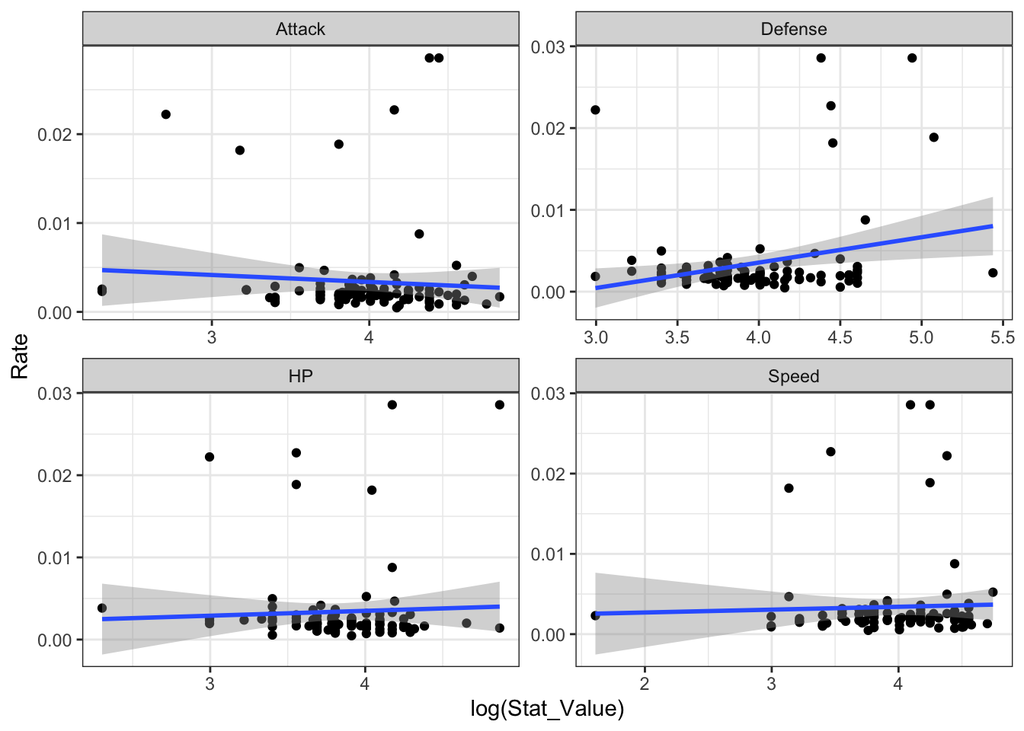

```r
pokemon_merged_3b <- pokemon_merged %>%
                      gather("HP", "Attack", "Defense", "Speed",
                             key = "Stat_Type", value = "Stat_Value")

ggplot(pokemon_merged_3b, aes(x = log(Stat_Value), y = Rate))+
  geom_point()+
  geom_smooth(method = "lm", se = TRUE)+
  facet_wrap(~Stat_Type, nrow = 2, scales = "free")+
  theme_bw()
```

```r
# Looks like there is not a relationship between a Pokemon's stats
#   and its shiny rate, except for maybe defense vs shiny rate has
#   a positive trend. But I'm not convinced just by this graph.
```

**Q3c** What is a quick way to get a dataset for only the pokemon stats that do not have shiny rates in the wild?

```r
pokemon_merged <- pokedat %>%
                    anti_join(shiny_1d,  c("Name" = "Pokemon_Name"))

pokemon_merged
```

```
## # A tibble: 470 × 15
##    Number Name    Type_1 Type_2 Total    HP Attack Defense Speed Gener…¹ isLeg…²
##     <dbl> <chr>   <chr>  <chr>  <dbl> <dbl>  <dbl>   <dbl> <dbl>   <dbl> <lgl>
##  1      2 Ivysaur Grass  Poison   405    60     62      63    60       1 FALSE
##  2      3 Venusa… Grass  Poison   525    80     82      83    80       1 FALSE
##  3      5 Charme… Fire   <NA>     405    58     64      58    80       1 FALSE
##  4      6 Chariz… Fire   Flying   534    78     84      78   100       1 FALSE
##  5      8 Wartor… Water  <NA>     405    59     63      80    58       1 FALSE
##  6      9 Blasto… Water  <NA>     530    79     83     100    78       1 FALSE
##  7     11 Metapod Bug    <NA>     205    50     20      55    30       1 FALSE
##  8     12 Butter… Bug    Flying   395    60     45      50    70       1 FALSE
##  9     13 Weedle  Bug    Poison   195    40     35      30    50       1 FALSE
## 10     14 Kakuna  Bug    Poison   205    45     25      50    35       1 FALSE
## # … with 460 more rows, 4 more variables: Color <chr>, Pr_Male <dbl>,
## #   Height_m <dbl>, Weight_kg <dbl>, and abbreviated variable names
## #   ¹Generation, ²isLegendary
```

```r
# Note here that you do not have any shiny rate data in the new table.
```